# Part II - (Ford GoBike System Data Analysis)

## by (Passy Mukami Miano)

## Investigation Overview

> In this analysis I want to share insights that could help us understand bike usage among users. My presentation will be focused on trends of bike usage during different hours of the day and during different weekdays among different users.

## Dataset Overview

> The dataset contains information about 183,412 individual rides made in the Ford GoBike bike-sharing system covering the greater San Fransisco Bay area. The dataset has several features which include: duration in seconds, start_time, end_time, user_type, member_birth_year, member_gender, start_station_name, end_station_name and other bike trip information.

## Distribution of Bike Ride Duration in Minutes

Trip duration takes a long range of values so we converted to a log scale. The didtribution is unimodal and fairy symmetric with a top peak between 8 and 10 minutes. Most of the bike rides are also less than 30 minutes.

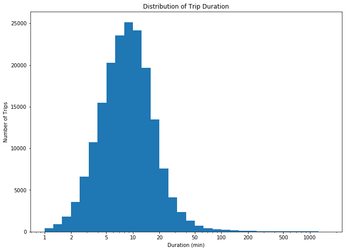

## Distribution of Bikes Rides at Hours of the Day

A bimodal distribution can be observed with two peaks at 8am and 5pm. This may because they are commute hours and hence the busiest time of the day. We can also observe that the least number of rides are made between 1am and 4am which is when most people are asleep.

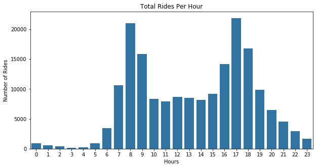

[figure not shown]